# Word Frequencies

Introduction to Text as Data

Amber Boydstun & Cory Struthers

January 25-27, 2024

### Introduction

The bag of words model is the prevailing approach to text representation. The fundamental concept is straightforward: we represent each document by a count of how many times each word appears in it. Think of taking all the words in a given document (or set of documents) and shaking them all up in a bag so they are no longer in order.

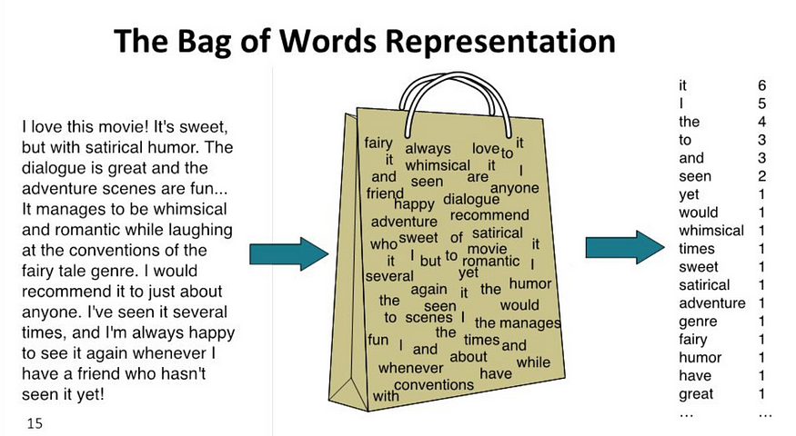

We’ll demonstrate word frequencies with an example using (what was once) Twitter data. During the 2016 presidential election campaigns, people noticed that when presidential candidate Donald Trump posted positive tweets, they came from an iPhone. When he posted negative and angrier tweets, they came from an Android. Some speculated that Trump’s Android and iPhone tweets were written by different people.

We’ll explore this possibility using [Twitter data collected from David Robinson](http://varianceexplained.org/r/trump-tweets/) to examine which words were most common among different phone types.

In this module, we’ll need the following packages:

```r
# Load packages
require(tidyverse)
require(quanteda)
require(quanteda.textstats)
require(quanteda.textplots)
library(stringr)
library(ggplot2)
library(ggpubr)

# Set working directory
setwd("~/Dropbox/text-as-data-JUST-CORY-AND-AMBER/modules_2024/data/")
getwd() # view working directory
```

After importing the data from Robinson’s website, we added a new variable that indicates whether the tweet was generated from an iPhone or Android.

We then converted the text to a corpus.

First, we turn the corpus into a tokens object.

```r
# Read in corpus
trump_tweets_corp = readRDS("trump_tweet_corp.rds")
head(docvars(trump_tweets_corp),10)
```

|  | X | id | source | created |
| --- | --- | --- | --- | --- |
| 1 | 1 | 7.626699e+17 | Android | 2016-08-08 15:20:44 |
| 2 | 2 | 7.626416e+17 | iPhone | 2016-08-08 13:28:20 |
| 3 | 3 | 7.624397e+17 | iPhone | 2016-08-08 00:05:54 |
| 4 | 4 | 7.624254e+17 | Android | 2016-08-07 23:09:08 |
| 5 | 5 | 7.624009e+17 | Android | 2016-08-07 21:31:46 |
| 6 | 6 | 7.622845e+17 | Android | 2016-08-07 13:49:29 |
| 7 | 7 | 7.621109e+17 | iPhone | 2016-08-07 02:19:37 |
| 8 | 8 | 7.621069e+17 | iPhone | 2016-08-07 02:03:39 |
| 9 | 9 | 7.621044e+17 | Android | 2016-08-07 01:53:45 |
| 10 | 10 | 7.620164e+17 | iPhone | 2016-08-06 20:04:08 |

```r
# Transform to tokens
trump_tweet_toks = trump_tweets_corp  %>%
    tokens(remove_punct = TRUE,
           remove_numbers = TRUE,
           remove_symbols = TRUE,
           remove_url = TRUE) %>%
    tokens_tolower() %>%
    tokens_remove(stopwords("english"), padding=TRUE)

# Find collocations
trump_tweet_coll = textstat_collocations(trump_tweet_toks, size = 2:3, min_count = 10)
trump_tweet_coll
```

|  | collocation | count | count_nested | length | lambda | z |
| --- | --- | --- | --- | --- | --- | --- |
| 1 | hillary clinton | 74 | 61 | 2 | 6.656281 | 24.772102 |
| 2 | make america | 51 | 51 | 2 | 7.327020 | 23.812451 |
| 3 | crooked hillary | 115 | 92 | 2 | 8.694839 | 21.733306 |
| 4 | #makeamericagreatagain #trump2016 | 51 | 39 | 2 | 6.161018 | 21.245207 |
| 5 | america great | 39 | 39 | 2 | 4.966026 | 20.896494 |
| 6 | ted cruz | 39 | 28 | 2 | 7.620193 | 20.723160 |
| 7 | last night | 15 | 14 | 2 | 7.679049 | 16.167569 |
| 8 | bernie sanders | 27 | 14 | 2 | 8.724701 | 15.794226 |
| 9 | president obama | 14 | 8 | 2 | 6.257737 | 15.379512 |
| 10 | failing @nytimes | 14 | 9 | 2 | 8.510715 | 14.643502 |

[output cut: 17 more lines]

```r
# Add collocations to existing tokens document
trump_toks_all =  tokens_compound(trump_tweet_toks, trump_tweet_coll, concatenator = " ") %>%
    tokens_select(padding=FALSE) %>% # remove padding
    tokens_wordstem # stem words after adding collocations
tail(trump_toks_all,15)
```

```
## Tokens consisting of 15 documents and 4 docvars.
## text1376 :
##  [1] "@sprinklermanus"  "@cnn"             "@realdonaldtrump" "spend"
##  [5] "million"          "still"            "go"               "win"
##  [9] "go"               "donald trump"
##
## text1377 :
##  [1] "@jallenaip" "hillari"    "said"       "fog"        "war"
##  [6] "explan"     "lie"        "benghazi"   "fog"        "allow"
## [11] "wh"         "vote"
## [ ... and 2 more ]
##
## text1378 :
## [1] "happi"     "new"       "year"      "#maralago" "thank"     "great"
## [7] "famili"    "support"
##
## text1379 :
## [1] "#happynewyearamerica"
##
## text1380 :
## [1] "happi" "new"   "year"  "amp"   "thank"
##
## text1381 :
##  [1] "phoenix" "just"    "report"  "wors"    "shape"   "ever"    "wait"
##  [8] "horrend" "peopl"   "die"     "fix"
##
## [ reached max_ndoc ... 9 more documents ]
```

### Create document frequency matrix (DFM)

After tokenization, we move to the next step. We use `dfm()` to convert the corpus of documents to a document-feature matrix (DFM), which is essentially a massive table where every row is a document in the corpus and every column is a token (recall, word or phrase).

The values in the cells show the number of times a token appears in the document.

```r
# Create a document-feature matrix
trump_tweet_dfm = dfm(trump_toks_all)
trump_tweet_dfm
```

```
## Document-feature matrix of: 1,390 documents, 2,929 features (99.69% sparse) and 4 docvars.
##        features
## docs    econom polici speech carri live enjoy join fayettevill north carolina
##   text1      1      1      1     1    1     1    0           0     0        0
##   text2      0      0      0     0    0     0    1           1     1        1
##   text3      0      0      0     0    0     0    0           0     0        0
##   text4      0      0      0     0    0     0    0           0     0        0
##   text5      0      0      0     0    0     0    0           0     0        0
##   text6      0      0      0     0    0     0    0           0     0        0
## [ reached max_ndoc ... 1,384 more documents, reached max_nfeat ... 2,919 more features ]
```

```r
# Number of features (i.e., unique tokens)
nfeat(trump_tweet_dfm)
```

```
## [1] 2929
```

```r
# Examine sums across documents
head(colSums(trump_tweet_dfm),50)
```

```
##        econom        polici        speech         carri          live
##             5             7            34             2             9
##         enjoy          join   fayettevill         north      carolina
##            36            49             1             8             7
##      tomorrow          even           6pm        ticket           now
##            25            33             2            16            54
##         avail        #icymi         media        apolog         trump
##             3             2            47             5           123
##       michael         morel   lightweight        former           act
##             7             1            15             4             4
##      director           man          made       serious           bad
##             2             9            22             3            55
##          call         total       clinton        flunki            go
##            26            59            32             3            61
##         crazi       distort          mani         thing        purpos
##            12             2            58            22             3
##        crimea       nuclear          babi          much     dishonest
##             3             3             1            34            23
##           see         mayor      stephani rawlings-blak      baltimor
##            38             4             1             1             2
```

Some dfms are very large, involving hundreds of thousands of documents and millions of features. Features within those documents may be used rarely across the whole corpus, or used many times but only in a single document. Many text analysis methods do not infer meaning from terms mentioned very few times, and retaining all terms in really large corpora increases computational complexity.

Thus, the researcher can “trim” the dfm to exclude infrequent terms using `dfm_trim`. When used appropriately, trimming can decrease processing time without losing quality. In fact, reducing *sparseness* or *sparsity* in the matrix (i.e., the proportion of cells that have zero counts) is particularly important for more complex computational tasks in order to avoid over-fitting and using memory.

- `min_termfreq` removes any features that occur less than *n* times in the corpus (no matter the distribution across documents).
- `min_docfreq` removes any features that occur in less than *n* times across *documents*.
- `docfreq_type` (an option) specifies a count or proportion.

```r
# Pipe grouping through trimming step
trump_tweet_dfm_trim = dfm(trump_tweet_dfm) %>%
                       dfm_trim(min_termfreq = 10, min_docfreq = 10, docfreq_type = "count") %>%
                       dfm_group(groups = source)
print(trump_tweet_dfm_trim)
```

```
## Document-feature matrix of: 2 documents, 291 features (2.41% sparse) and 1 docvar.
##          features
## docs      speech enjoy join tomorrow even ticket now media trump lightweight
##   Android     24    19    3        3   19      2  37    40    95           6
##   iPhone      10    17   46       22   14     14  17     7    28           9
## [ reached max_nfeat ... 281 more features ]
```

Depending on the question, ubiquitous terms can also have little meaning. `quanteda` offers a `max` equivalent of the above but we don’t suggest using it as often, in part because common terms may not be distributed evenly across groups we care about.

### Calculate basic word frequencies

The `textstat_frequency()` function in `quanteda.textstats package` is a useful function for calculating term frequencies in a corpus of text data. In addition to providing feature counts, it ranks features and provides each feature’s document frequency.

Note that you must use `group` to get group-level frequencies when you apply `textstat_frequency`.

```r
trump_tweet_words_freq = dfm(trump_tweet_dfm_trim) %>%
    textstat_frequency(groups = source) # Grouping the term frequencies by source
head(trump_tweet_words_freq)
```

|  | feature | frequency | rank | docfreq | group |
| --- | --- | --- | --- | --- | --- |
| 1 | @realdonaldtrump | 125 | 1 | 1 | Android |
| 2 | trump | 95 | 2 | 1 | Android |
| 3 | great | 95 | 2 | 1 | Android |
| 4 | peopl | 75 | 4 | 1 | Android |
| 5 | just | 66 | 5 | 1 | Android |
| 6 | thank | 63 | 6 | 1 | Android |

### Visualizing word frequencies

After trimming (as appropriate), we can use the `textplot_wordcloud` function to create wordcloud of the trimmed dfm.

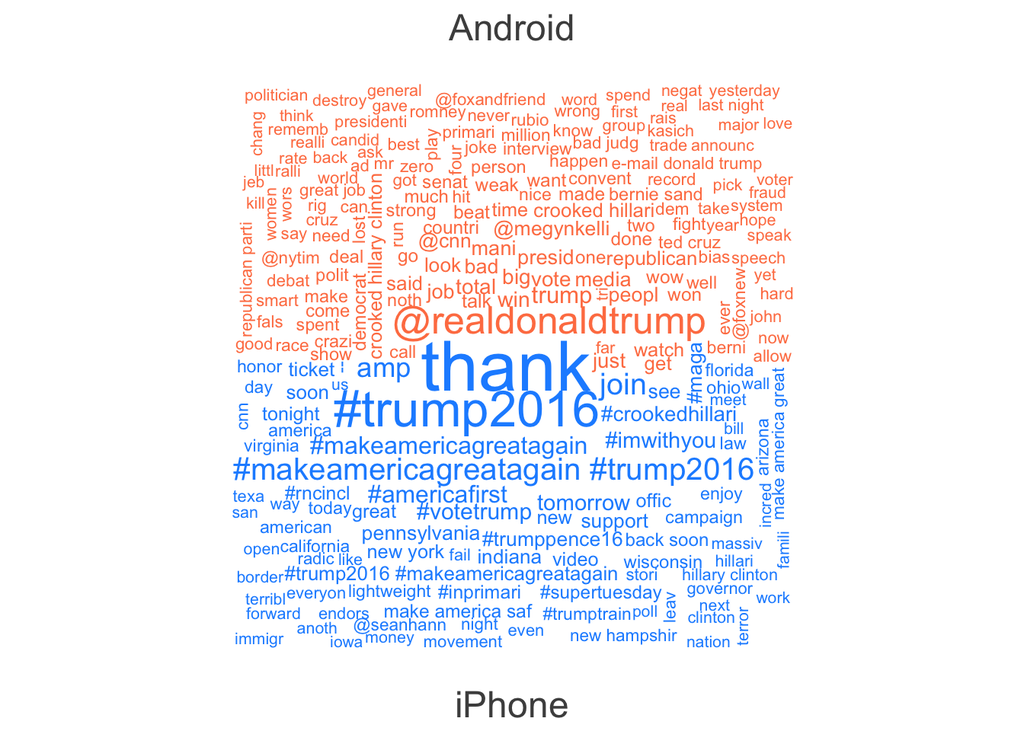

```r
set.seed(132) # Set seed so figure can be reproduced
textplot_wordcloud(trump_tweet_dfm_trim, comparison = TRUE, max_words = 250, color = c("coral","dodgerblue"), min_size=0.9)
```

Let’s also plot the count of the top 15 most frequent words used in Trump’s tweets from Android and from iPhone.

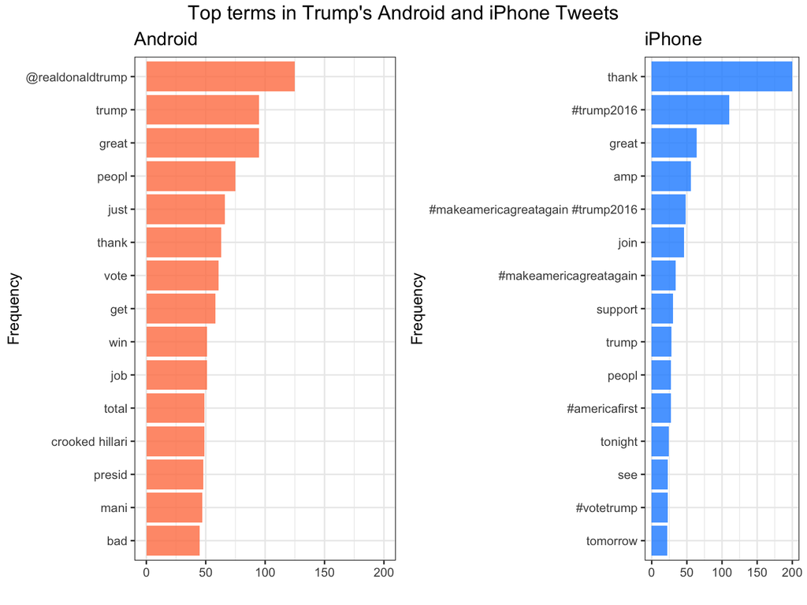

```r
# First create dfs with top 15 features
android15_df = trump_tweet_words_freq %>%
    filter(group == "Android") %>%
    head(15)
iphone15_df = trump_tweet_words_freq %>%
    filter(group == "iPhone") %>%
    head(15)

# Plot and arrange side by side
android15_plot = ggplot(data = android15_df, aes(x = reorder(feature, frequency), y = frequency)) +
    geom_col(stat = "identity", alpha = 0.8, fill = "coral",
             position = position_dodge(width = 0.8)) +
    scale_y_continuous(limits = c(0, 200)) +
    xlab("Frequency") + ylab("") +
    ggtitle("Android") +
    coord_flip() +
    theme_bw()

iphone15_plot = ggplot(data = iphone15_df, aes(x = reorder(feature, frequency), y = frequency)) +
    geom_col(stat = "identity", alpha = 0.8, fill = "dodgerblue",
             position = position_dodge(width = 0.8)) +
    scale_y_continuous(limits = c(0, 200)) +
    xlab("Frequency") + ylab("") +
    ggtitle("iPhone") +
    coord_flip() +
    theme_bw()

ggpubr::ggarrange(android15_plot, iphone15_plot) %>%
  annotate_figure(top = text_grob("Top terms in Trump's Android and iPhone Tweets",  size = 14))
```

### Homework

#### Discussion Question:

Say you had ten poems, five describing the winter season and five describing the summer. The words “snow” and “cold” appear a handful of times in the winter poems and not at all in the summer poems. Imagine the result of the word frequency measure we’ve constructed in this module. Would the result adequately capture the importance of the words “cold” and “snow” to the winter concept?

#### Coding Question:

1. Generate a list of the top terms/concepts in the immigration twitter data you tokenized from the pre-processing module, by year.
2. Create a word cloud of top terms representing each year. Do they seem to change once Trump takes office in 2017?